# Week 8 - Homework

Author

Linnea Nordli

# Functional Programming

## Homework Instructions

- Create any dataset you’d like
- Write *two* useful functions:
  - One that creates a plot
  - One that does something else
- Create a Quarto document showing:
  - At least 2 examples per function
  - Evidence of the function’s flexibility

## Load libraries

```r
library(tidyverse)
library(PNWColors)
library(sf)
library(maptiles)
library(palmerpenguins)
```

## Import data

```r
tortoise <- readr::read_csv('https://raw.githubusercontent.com/rfordatascience/tidytuesday/main/data/2026/2026-03-03/tortoise_body_condition_cleaned.csv')
```

## Conversion Function: Convert fluid ounces to milliliters.

If we collect a water sample but record it in fluid ounces (Imperial), we would want to easily convert to milliliters (Metric) I’ve created a function to convert this.

```r
fl_oz_to_ml <- function(fl_oz){
  ml <- (30/1)*(fl_oz)
  return(ml)
}
```

### Example 1: Confirming that the function works, with the base conversion 1 oz = 30 ml (approximately)

```r
fl_oz_to_ml(1)
```

```
[1] 30
```

### Example 2: If we input 20 oz into the function, the output is 600ml.

```r
fl_oz_to_ml(20)
```

```
[1] 600
```

## Plot Function: Boxplot

Creating the plot function to create boxplots. Add color palette from PNW Colors, remove outliers, and add theme.

```r
boxplot <- function(data, x, y, fill, group) {
  pal <- pnw_palette("Sailboat", 3, type = "discrete")

  ggplot(data, aes(x = {{x}}, y = {{y}}, fill = {{fill}}, group = {{group}}))+
    geom_boxplot(outlier.shape = NA)+
    scale_fill_manual(values = pal)+
    theme_bw()
}
```

### Example 1

Use palmerpenguins dataset to plot penguin species and body mass.

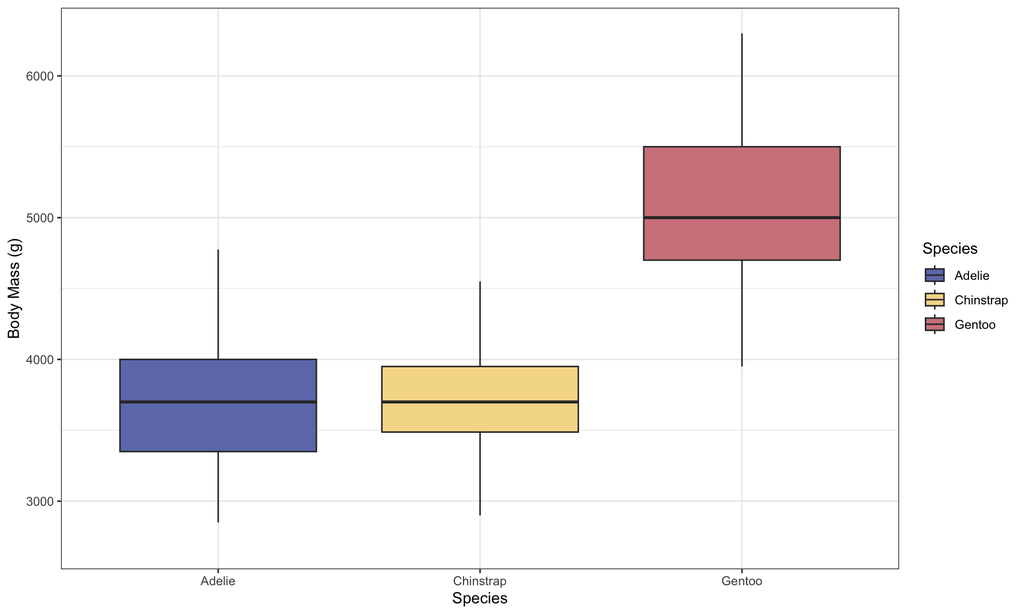

Figure 1: A boxplot showing penguin body mass (g) by penguin species (Adelie, Chinstrap, Gentoo).

```r
boxplot(penguins, x = species, y = body_mass_g, fill = species, group = species)+
  labs(x="Species", y="Body Mass (g)", fill = "Species") # add labels
```

### Example 2

Use TidyTuesday dataset *Golem Grad Tortoise Data* to plot tortoise mass and carapace length grouped by locality.

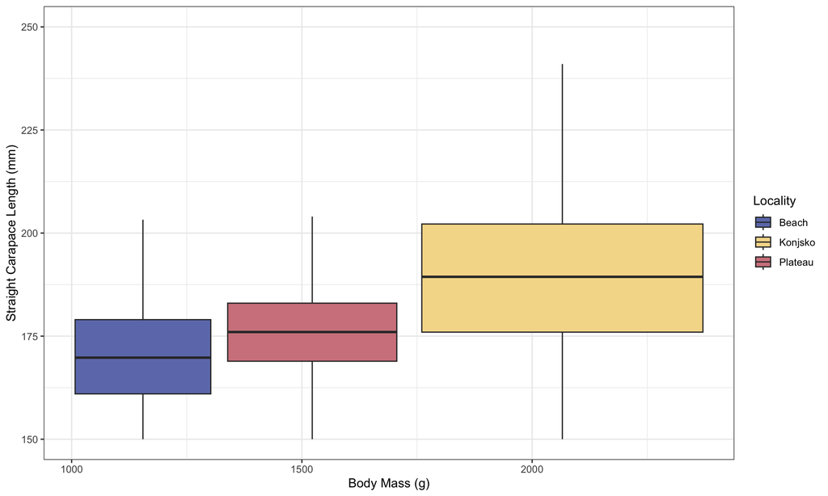

Figure 2: A boxplot showing Hermann’s tortoises’ straight carapace length (mm) by and body mass (g). Colors indicate location (Beach, Konjsko, Plateau) of tortoises recorded in Lake Prespa in North Macedonia.

```r
boxplot(tortoise, x = body_mass_grams, y = straight_carapace_length_mm, fill = locality, group = locality)+
  labs(x="Body Mass (g)", y="Straight Carapace Length (mm)", fill = "Locality") # add labels
```

## References

**Figure 1**. Horst AM, Hill AP, Gorman KB (2020). palmerpenguins: Palmer Archipelago (Antarctica) penguin data. R package version 0.1.0. [GitHub Repository](https://allisonhorst.github.io/palmerpenguins/) . [DOI](https://doi.org/10.5281/zenodo.3960218)

**Figure 2**. Arsovski, D., X. Bonnet, A. Golubović, and L. Tomović. 2026. “Sex Ratio Bias Triggers Demographic Suicide in a Dense Tortoise Population.” Ecology Letters 29, no. 1: e70296. [DOI](https://doi.org/10.1111/ele.70296).